# Korea Income Distribution

coop711

2015년 4월 12일

## Data Management

자료 입력

```r
income.kor<-read.table("../data/labor_income_kor.txt", header=T, row.names=1)
income.kor
```

```
##          Earners... Income...
## 0-5            19.1       1.7
## 5-10           12.3       3.6
## 10-20          22.8      12.8
## 20-30          14.4      13.6
## 30-40           9.8      13.0
## 40-60          12.0      22.5
## 60-80           5.4      14.1
## 80-100          2.3       7.8
## 100-200         1.6       7.7
## 200-300         0.1       1.2
## 300-500         0.1       0.8
## 500-1000        0.0       0.6
## 1000-           0.0       0.6
```

```r
str(income.kor)
```

```
## 'data.frame':    13 obs. of  2 variables:
##  $ Earners...: num  19.1 12.3 22.8 14.4 9.8 12 5.4 2.3 1.6 0.1 ...
##  $ Income... : num  1.7 3.6 12.8 13.6 13 22.5 14.1 7.8 7.7 1.2 ...
```

변수명을 조정하고, 다시 확인.

```r
dimnames(income.kor)[[2]]<-c("Earners(%)", "Income(%)")
income.kor
```

```
##          Earners(%) Income(%)
## 0-5            19.1       1.7
## 5-10           12.3       3.6
## 10-20          22.8      12.8
## 20-30          14.4      13.6
## 30-40           9.8      13.0
## 40-60          12.0      22.5
## 60-80           5.4      14.1
## 80-100          2.3       7.8
## 100-200         1.6       7.7
## 200-300         0.1       1.2
## 300-500         0.1       0.8
## 500-1000        0.0       0.6
## 1000-           0.0       0.6
```

barplot() 을 그리기 위하여 height 를 설정하려면 width를 파악하여야 함. 그러기 위해서 소득 구간을 row.names의 구간으로부터 설정.

```r
income.breaks<-c(0,5,10,20,30,40,60,80,100,200,300,500,1000,2000)
```

width에 해당하는 각 소득구간의 폭을 계산

```r
income.widths<-diff(income.breaks)
income.widths
```

```
##  [1]    5    5   10   10   10   20   20   20  100  100  200  500 1000
```

각 기둥의 면적이 해당 소득구간의 퍼센티지와 같게 해주려면 각 퍼센티지를 width 로 나눠줘야 함.

```r
height.workers<-income.kor[,1]/income.widths
round(height.workers, digits=3)
```

```
##  [1] 3.820 2.460 2.280 1.440 0.980 0.600 0.270 0.115 0.016 0.001 0.000
## [12] 0.000 0.000
```

아무런 argument 도 설정하지 않고 barplot() 을 그리면

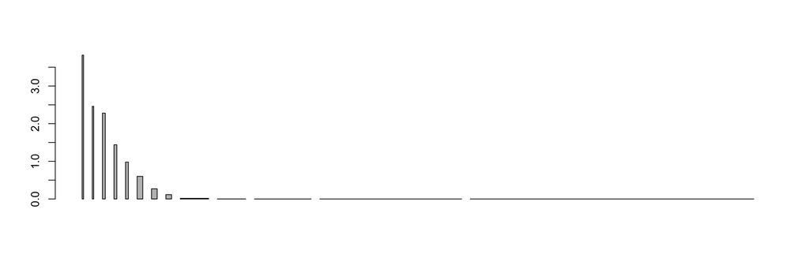

```r
barplot(height.workers, income.widths)
```

각 bar 의 이름을 row.names에서 가져오면

```r
names.bar<-rownames(income.kor)
names.bar
```

```
##  [1] "0-5"      "5-10"     "10-20"    "20-30"    "30-40"    "40-60"
##  [7] "60-80"    "80-100"   "100-200"  "200-300"  "300-500"  "500-1000"
## [13] "1000-"
```

bar 의 이름을 넣어 다시 그리되, bar 사이의 공간을 없애면

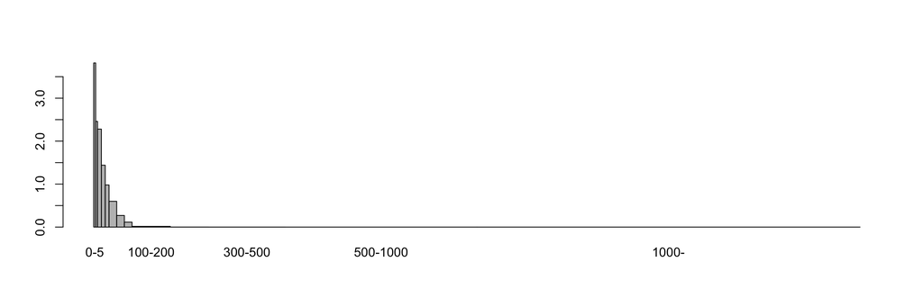

```r
barplot(height.workers, income.widths, space=0, names.arg=names.bar)
```

```r
income.kor.2<-income.kor[1:11,]
income.kor.2[11,]<-apply(income.kor[11:13,], 2, sum)
income.kor.2
```

```
##         Earners(%) Income(%)
## 0-5           19.1       1.7
## 5-10          12.3       3.6
## 10-20         22.8      12.8
## 20-30         14.4      13.6
## 30-40          9.8      13.0
## 40-60         12.0      22.5
## 60-80          5.4      14.1
## 80-100         2.3       7.8
## 100-200        1.6       7.7
## 200-300        0.1       1.2
## 300-500        0.1       2.0
```

```r
rownames(income.kor.2)
```

```
##  [1] "0-5"     "5-10"    "10-20"   "20-30"   "30-40"   "40-60"   "60-80"
##  [8] "80-100"  "100-200" "200-300" "300-500"
```

```r
rownames(income.kor.2)[11]<-"300-  "
income.kor.2
```

```
##         Earners(%) Income(%)
## 0-5           19.1       1.7
## 5-10          12.3       3.6
## 10-20         22.8      12.8
## 20-30         14.4      13.6
## 30-40          9.8      13.0
## 40-60         12.0      22.5
## 60-80          5.4      14.1
## 80-100         2.3       7.8
## 100-200        1.6       7.7
## 200-300        0.1       1.2
## 300-           0.1       2.0
```

```r
income.breaks.2<-c(0,5,10,20,30,40,60,80,100,200,300,500)
income.widths.2<-diff(income.breaks.2)
height.workers.2<-income.kor.2[,1]/income.widths.2
names.bar.2<-rownames(income.kor.2)
```

다시 barplot()을 작동시키되 회색 대신 흰색을 넣고, bar 사이의 공간을 없애면

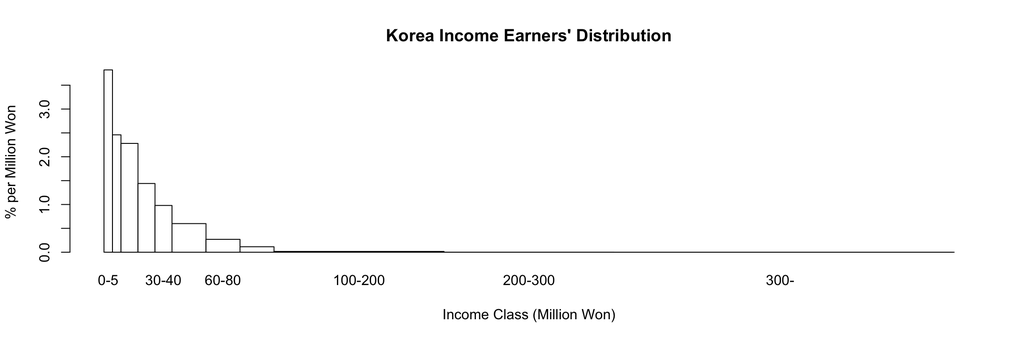

```r
barplot(height.workers.2, income.widths.2, names.arg=names.bar.2, space=0, col="white")
title(main="Korea Income Earners' Distribution", xlab="Income Class (Million Won)", ylab="% per Million Won")
```

1억 이상의 구간을 합치기 위하여 자료를 다시 손보면,

```r
income.kor.3<-income.kor.2[1:9,]
income.kor.3[9,]<-apply(income.kor.2[9:11,], 2, sum)
rownames(income.kor.3)[9]<-"100-   "
income.breaks.3<-c(0,5,10,20,30,40,60,80,100,200)
income.widths.3<-diff(income.breaks.3)
height.workers.3<-income.kor.3[,1]/income.widths.3
names.bar.3<-rownames(income.kor.3)
```

1억 이상의 구간을 합쳐 barplot을 그리면,

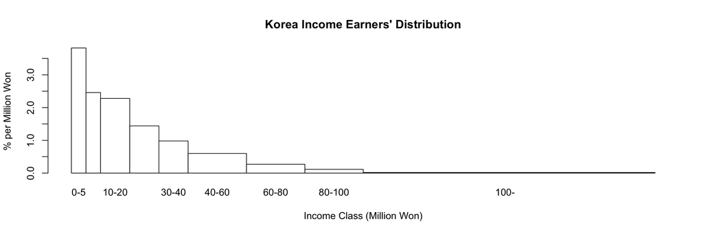

```r
barplot(height.workers.3, income.widths.3, names.arg=names.bar.3, space=0, col="white")
title(main="Korea Income Earners' Distribution", xlab="Income Class (Million Won)", ylab="% per Million Won")
```

같은 방법으로 소득규모에 대하여 세 개의 barplot을 그리려면, 우선 자료를 정리하고.

```r
height.income<-income.kor[,2]/income.widths
height.income.2<-income.kor.2[,2]/income.widths.2
height.income.3<-income.kor.3[,2]/income.widths.3
```

세 개의 barplot을 연속으로 그리기 위하여 par(mfrow=c(3,1)) 설정

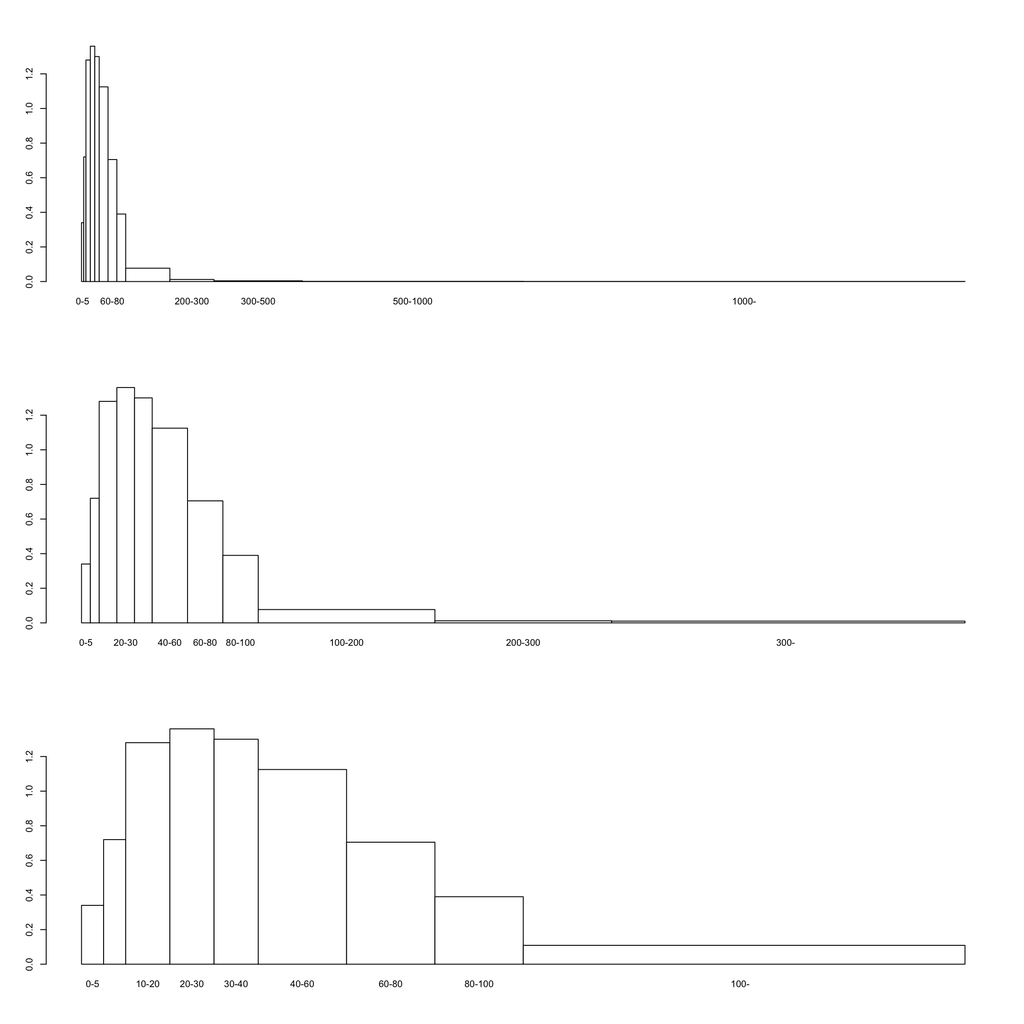

```r
par(mfrow=c(3,1))
barplot(height.income, income.widths, names.arg=names.bar, space=0, col="white")
barplot(height.income.2, income.widths.2, names.arg=names.bar.2, space=0, col="white")
barplot(height.income.3, income.widths.3, names.arg=names.bar.3, space=0, col="white")
```

```r
par(mfrow=c(1,1))
```

barplot 보다 누적도표가 분포의 윤곽을 살피는 데 더 낫다는 점을 상기하면, 누적분포를 구하는 일부터 시작하여야 함. 자료로부터 이미 아는 사실이지만, cumsum()함수의 활용겸 확인차 계산해보면

```r
income.kor.cum<-apply(income.kor, 2, cumsum)
income.kor.cum
```

```
##          Earners(%) Income(%)
## 0-5            19.1       1.7
## 5-10           31.4       5.3
## 10-20          54.2      18.1
## 20-30          68.6      31.7
## 30-40          78.4      44.7
## 40-60          90.4      67.2
## 60-80          95.8      81.3
## 80-100         98.1      89.1
## 100-200        99.7      96.8
## 200-300        99.8      98.0
## 300-500        99.9      98.8
## 500-1000       99.9      99.4
## 1000-          99.9     100.0
```

누적분포의 각 계급은 `10-20`의 열리고 닫힌 구간이 아니라 한 쪽으로 열린 구간이어야 하고, 누적백분률임을 명시하려면

```r
income.class.cum<-paste(" -", income.breaks[2:length(income.breaks)], sep="")
dimnames(income.kor.cum)[[1]]<-income.class.cum
dimnames(income.kor.cum)[[2]]<-c("Earners.Cumulative(%)", "Income.Cumulative(%)")
income.kor.cum
```

```
##        Earners.Cumulative(%) Income.Cumulative(%)
##  -5                     19.1                  1.7
##  -10                    31.4                  5.3
##  -20                    54.2                 18.1
##  -30                    68.6                 31.7
##  -40                    78.4                 44.7
##  -60                    90.4                 67.2
##  -80                    95.8                 81.3
##  -100                   98.1                 89.1
##  -200                   99.7                 96.8
##  -300                   99.8                 98.0
##  -500                   99.9                 98.8
##  -1000                  99.9                 99.4
##  -2000                  99.9                100.0
```

누적도표를 그리려면 첫 시작은 (0, 0)이어야 함에 유의. 마침 income.breaks 와 맞춰보면 income.kor.cum 의 첫 행을 0으로만 추가해 주면 되는 일임. xlim 을 좁혀가면서 분포 윤곽 파악.

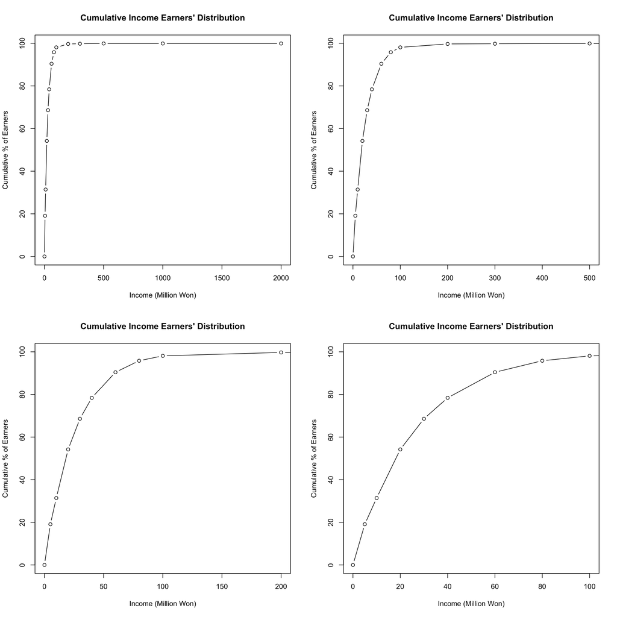

```r
par(mfrow=c(2,2))
plot(x=income.breaks, y=c(0,income.kor.cum[,1]), type="b", ann=F)
title(main="Cumulative Income Earners' Distribution", xlab="Income (Million Won)", ylab="Cumulative % of Earners")
plot(x=income.breaks, y=c(0,income.kor.cum[,1]), type="b", xlim=c(0,500), ann=F)
title(main="Cumulative Income Earners' Distribution", xlab="Income (Million Won)", ylab="Cumulative % of Earners")
plot(x=income.breaks, y=c(0,income.kor.cum[,1]), type="b", xlim=c(0,200), ann=F)
title(main="Cumulative Income Earners' Distribution", xlab="Income (Million Won)", ylab="Cumulative % of Earners")
plot(x=income.breaks, y=c(0,income.kor.cum[,1]), type="b", xlim=c(0,100), ann=F)
title(main="Cumulative Income Earners' Distribution", xlab="Income (Million Won)", ylab="Cumulative % of Earners")
```

```r
par(mfrow=c(1,1))
```

한가지 기억해 둘 사실은 누적분포의 윗 부분 면적이 바로 평균이라는 점. 누적분포가 히스토그램보다 나은 점 중의 하나가 분위를 찾기 쉬울 뿐 아니라 평균을 비교하는 것도 용이하다는 것임.

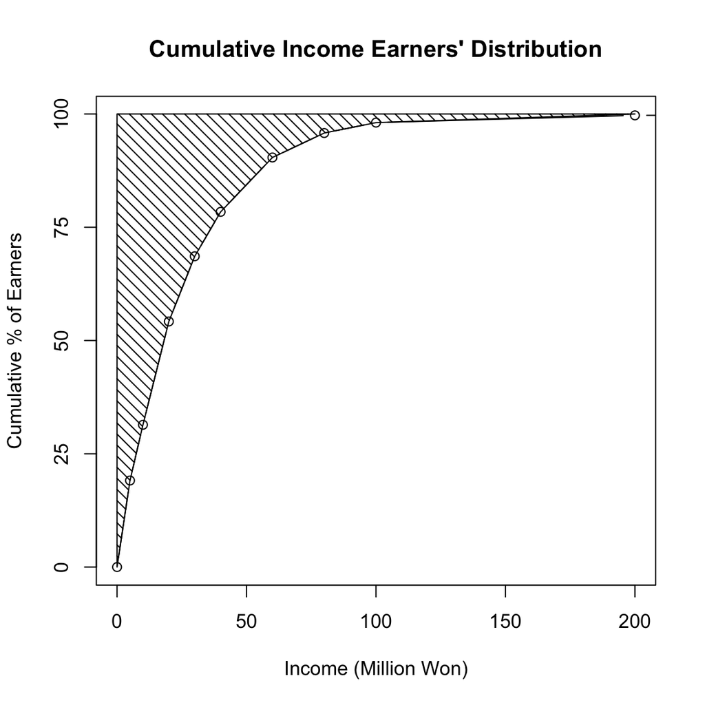

```r
plot(x=income.breaks, y=c(0,income.kor.cum[,1]), type="b", xlim=c(0,200), ann=F, yaxt="n")
axis(side=2, at=seq(0, 100, by=25), labels=seq(0, 100, by=25))
polygon(x=c(income.breaks[income.breaks < 200], 200, 0, 0), y=c(0, income.kor.cum[,1][income.breaks < 100], 100, 100, 0), density=15, angle=135)
title(main="Cumulative Income Earners' Distribution", xlab="Income (Million Won)", ylab="Cumulative % of Earners")
```

소득 자체의 누적분포에 대해서도 같은 방법으로 그려보면

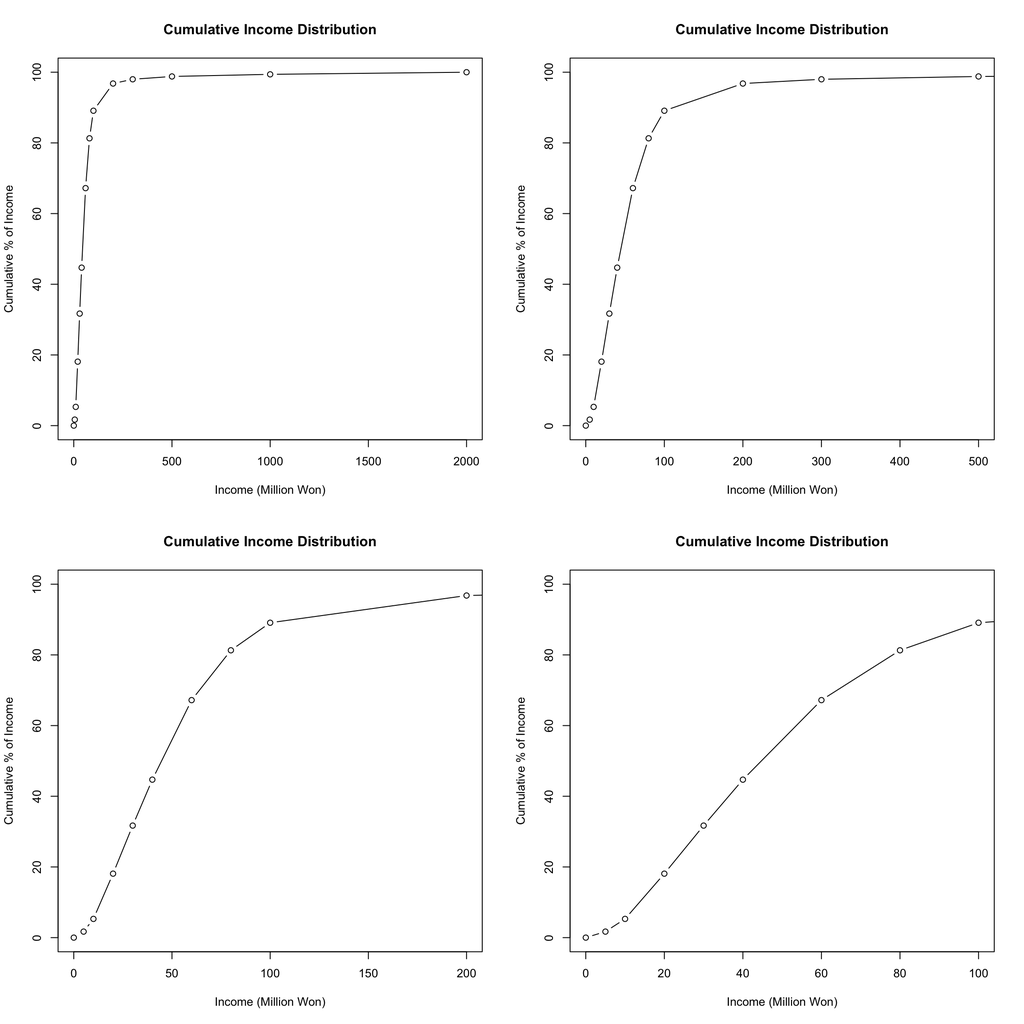

```r
par(mfrow=c(2,2))
plot(x=income.breaks, y=c(0,income.kor.cum[,2]), type="b", ann=F)
title(main="Cumulative Income Distribution", xlab="Income (Million Won)", ylab="Cumulative % of Income")
plot(x=income.breaks, y=c(0,income.kor.cum[,2]), type="b", xlim=c(0,500), ann=F)
title(main="Cumulative Income Distribution", xlab="Income (Million Won)", ylab="Cumulative % of Income")
plot(x=income.breaks, y=c(0,income.kor.cum[,2]), type="b", xlim=c(0,200), ann=F)
title(main="Cumulative Income Distribution", xlab="Income (Million Won)", ylab="Cumulative % of Income")
plot(x=income.breaks, y=c(0,income.kor.cum[,2]), type="b", xlim=c(0,100), ann=F)
title(main="Cumulative Income Distribution", xlab="Income (Million Won)", ylab="Cumulative % of Income")
```

```r
par(mfrow=c(1,1))
```

이제 두 누적분포를 한 장에 살피는 방법을 생각해보자. $x$ 축을 사람, $y$ 축을 소득으로 하여 두 점을 이어주면 어떤 결과가 나오는 지 살펴 보자.

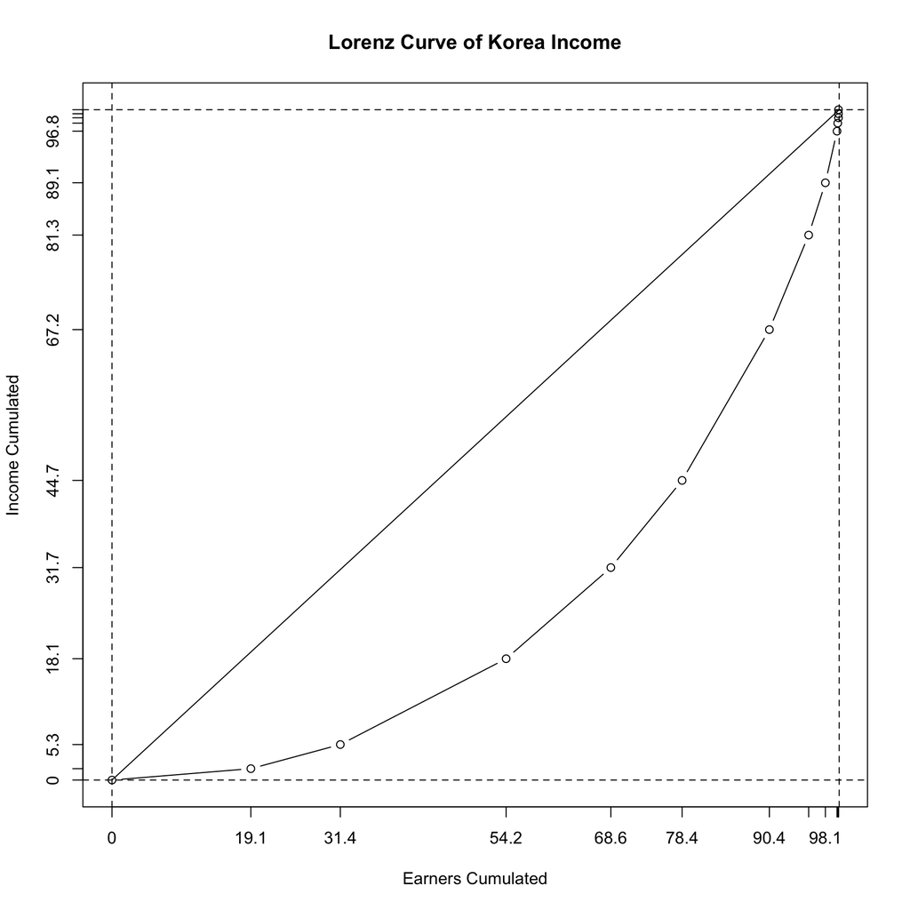

```r
earners<-c(0, income.kor.cum[,1])
income<-c(0, income.kor.cum[,2])
plot(x=earners, y=income, type="b", ann=F, xaxt="n", yaxt="n")
lines(x=0:100, y=0:100, type="l")
axis(side=1, at=earners, labels=earners)
axis(side=2, at=income, labels=income)
abline(h=c(0,100), lty=2)
abline(v=c(0,100), lty=2)
title(main="Lorenz Curve of Korea Income", xlab="Earners Cumulated", ylab="Income Cumulated")
```

초승달 부분에 빗금을 치고, 각 축의 눈금을 가능한 많이 표시하려면

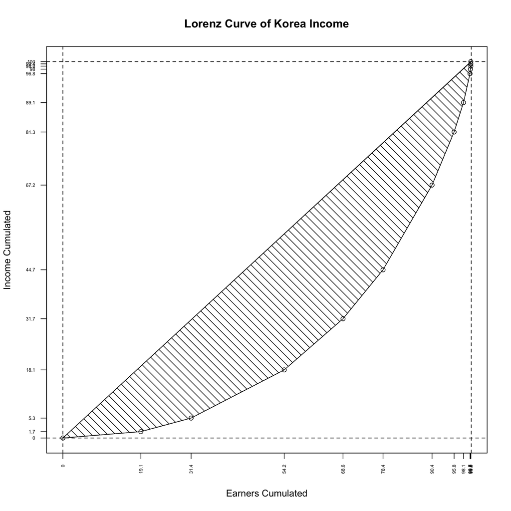

```r
plot(x=earners, y=income, type="b", ann=F, xaxt="n", yaxt="n")
lines(x=0:100, y=0:100, type="l")
axis(side=1, at=earners, labels=earners, las=2, cex.axis=0.5)
axis(side=2, at=income, labels=income, las=2, cex.axis=0.5)
abline(h=c(0,100), lty=2)
abline(v=c(0,100), lty=2)
title(main="Lorenz Curve of Korea Income", xlab="Earners Cumulated", ylab="Income Cumulated")
polygon(x=c(earners, 0), y=c(income,0), density=10, angle=135)
```

이 곡선의 이름은?